## Git & reproducible research

http://johanjunkka.com/r-course-git

## Keeping track of changes

[figure not shown]

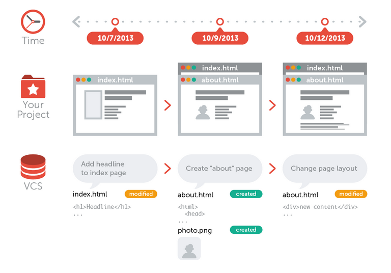

[figure not shown]

## Version control systems allows you to

- keep track of changes consistently
- jump between versions
- easily see what was changed between versions

Makes you write better code!

## Definitions

| **Working directory** | The project directory containing all project files and folders you which to have under version control. |
| --- | --- |
| **Repository** | The `.git` directory where the history of your project is stored. |
| **Commit** | A snapshot containing the state of the project at a certain point. |
| **HEAD** | Refers to the commit currently checked out in the working directory. |

## The Git model

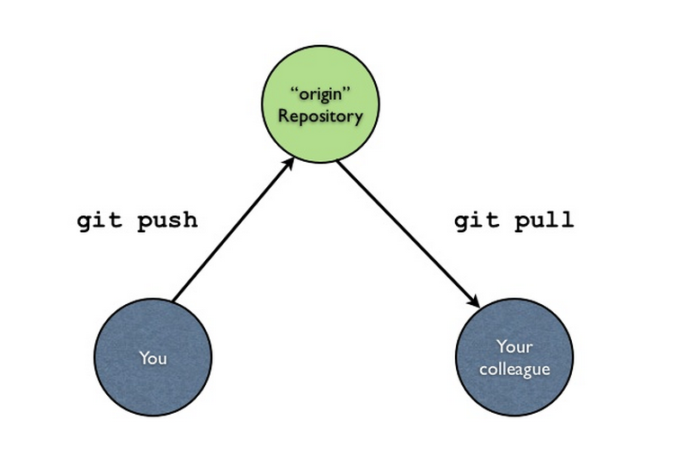

## The Git model

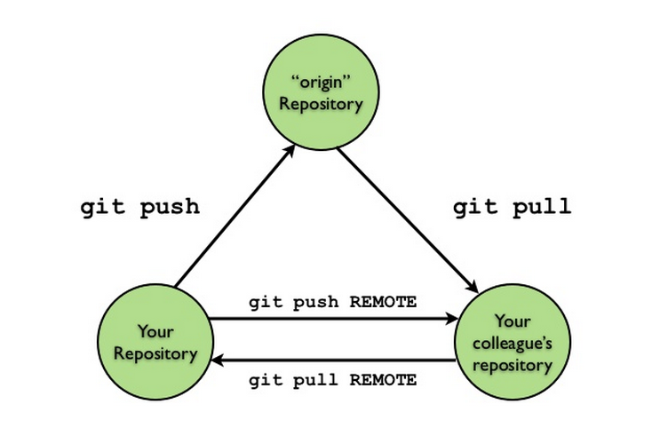

http://www.slideshare.net/lfittl/introduction-to-git-4642204

## Set up

- Install [GitHub for Windows](https://windows.github.com/)
- Config
- ssh

# Remote origins

- [GitHub](https://github.com) - Unlimited open source repos with unlimited contributors
- [BitBucket](https://bitbucket.org) - Unlimited private repositories, limited contributors
- [GitLab](https://about.gitlab.com) - Self hosted solution

## `git init`

Through RStudio

- New repo = easy
- Clone a repo = easy

## Version control an existing project

Need to use git in the shell

1. Navigate to your project root folder
2. run: `git init`
3. Creates a `.git` directory

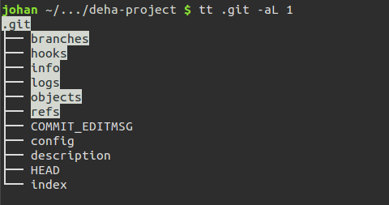

## The status of your project

```bash
git status
```

## Working with git

Update -> `stage` -> `commit`

## Jumping between versions

```
git checkout 04e85cb9
```

See RStudio log

## “Saving” to origin repository

1. Create a repository [on GitHub](https://github.com/new)

[figure not shown]

2. Add remote address to local repo

[figure not shown]

```bash
git remote add origin ADDRESS
git remote -v
```

In RStudio under Tools/Project options …/Git

## Making changes and pushing

When you add a remote to an existing repo

```bash
git push -u origin --all
```

## Git flow

Update -> `stage` -> `commit` -> **`push`**

```bash
git push origin master
```

`.gitignore`

Only keep the files necessary for reproduction.

i.e. only data & scripts **NOT** `.pdf` & `.html`

The `.gitignore` file holds a list of files to ignore

For example

```
.Rproj.user
.Rhistory
.RData
*.html
*.pdf
*_cache/
*_files/
```

## “Undo” changes

Made some changes to **ONE** file you regret.

```bash
git checkout filename
```

for example

```bash
git checkout index.Rmd
```

## Reset to a previous commit

1. find a commit `git log`
2. note the unique id - (the sha-id)
3. reset to that commit `git reset SHA-ID`

Reset one commit

```bash
git reset HEAD^
```

or two

```bash
git reset HEAD^^
```

## Don’t panic!

Did you just push half your hard drive to GitHub?

1. Delete public repo on github
2. remove .git/ folder

## Only last commit

Force github to reset!

```bash
git reset 93c1d75a8 --hard #commithash
git push -f origin  # as in force
```

## All together

http://onlywei.github.io/explain-git-with-d3/

## More

`git clone REPOADRESS` = start from an existing project

`git checkout -b BRANCH` = start a new branch

`git merge BRANCH` = merge changes from another branch into current

`git checkout BRANCH` = checkout an existing branch

`git checkout HASH` = checkout a previous commit

`git tag v1.0` = add tag to last commit, easier to find

`git push origin --tags` = because git doesn’t push tags automatically

# Resources

[Git official website](http://git-scm.com/)

[GitHub cheat-sheet](https://training.github.com/kit/downloads/github-git-cheat-sheet.pdf)

[GitHub training](https://training.github.com/)

[Getting Git Right | Atlassian Git Tutorial](https://www.atlassian.com/git/)